# Phase 1: Data Understanding and Exploratory Analysis

## Background and data source

The dataset is derived from Salam & El Hibaoui, *Power Consumption of Tetouan City* (UCI Machine Learning Repository). The original data record the active power consumed every 10 minutes by the three distribution zones of Tetouan (Morocco) during 2017.

For each (day $d$, hour $h$) pair we define the **hourly load factor**:

$$\mathrm{LF}(d, h) = \frac{\overline{P}(d, h)}{\max_{h'}
\overline{P}(d, h')}$$

where $\overline{P}(d,h) = \text{Zone1}(d,h) + \text{Zone2}(d,h) + \text{Zone3}(d,h)$ is the city-wide hourly mean power. By construction $\mathrm{LF}(d,h) \in [0, 1]$: the daily peak hour equals exactly 1, while the deepest off-peak hour yields the smallest value.

From the full $365 \times 24 \approx 8700$ cells a uniform random subsample of **2000 rows** was drawn. Values are clamped to $(10^{-3},\, 1 - 10^{-3})$ so that the **Beta log-density is finite at the boundaries** — a requirement for Bayesian inference with Stan.

## 1. Loading and initial inspection

```r
lf <- read.csv("hourly_load_factor.csv")

# Parse dates and add temporal variables
lf$date   <- mdy(lf$date)
lf$month  <- month(lf$date)
lf$season <- cut(lf$month,
                 breaks = c(0, 3, 6, 9, 12),
                 labels = c("Winter", "Spring", "Summer", "Autumn"),
                 include.lowest = FALSE)

cat("Dimensions:", nrow(lf), "rows x", ncol(lf), "columns\n")
```

```
## Dimensions: 2000 rows x 5 columns
```

```r
head(lf)
```

```
##         date hour load_factor month season
## 1 2017-03-18    0     0.67677     3 Winter
## 2 2017-01-18    1     0.53322     1 Winter
## 3 2017-07-07   18     0.75073     7 Summer
## 4 2017-06-17    4     0.61787     6 Spring
## 5 2017-06-02    9     0.58899     6 Spring
## 6 2017-04-06    6     0.51257     4 Spring
```

```r
cat("Missing values:", sum(is.na(lf$load_factor)), "\n")
```

```
## Missing values: 0
```

```r
cat("load_factor range: [", min(lf$load_factor), ",", max(lf$load_factor), "]\n")
```

```
## load_factor range: [ 0.42574 , 0.999 ]
```

```r
cat("Unique hours:", length(unique(lf$hour)), " (from", min(lf$hour), "to", max(lf$hour), ")\n")
```

```
## Unique hours: 24  (from 0 to 23 )
```

## 2. Descriptive statistics

```r
lf |>
  summarise(
    n      = n(),
    min    = round(min(load_factor), 4),
    q1     = round(quantile(load_factor, 0.25), 4),
    median = round(median(load_factor), 4),
    mean   = round(mean(load_factor), 4),
    q3     = round(quantile(load_factor, 0.75), 4),
    max    = round(max(load_factor), 4),
    sd     = round(sd(load_factor), 4)
  ) |>
  knitr::kable(caption = "Descriptive statistics of the load factor (n = 2000)")
```

Descriptive statistics of the load factor (n = 2000)

| n | min | q1 | median | mean | q3 | max | sd |
| --- | --- | --- | --- | --- | --- | --- | --- |
| 2000 | 0.4257 | 0.586 | 0.7329 | 0.7235 | 0.8042 | 0.999 | 0.1523 |

The distribution is left-skewed (median > mean), with the lower tail corresponding to nighttime off-peak hours. The effective range (~0.43–0.999) is wide, indicating that at peak hours the load factor reaches the upper clamping boundary.

## 3. Plot 1 — Overall histogram with kernel density

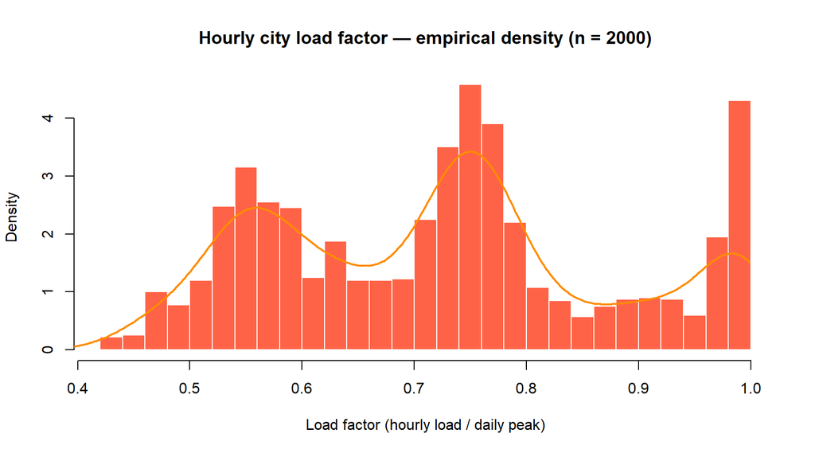

Empirical density of the load factor (n = 2000). The orange curve is the kernel density estimate.

```r
hist(lf$load_factor, breaks = 35, freq = FALSE,
     col = "tomato", border = "white",
     xlab = "Load factor (hourly load / daily peak)",
     main = "Hourly city load factor — empirical density (n = 2000)")
lines(density(lf$load_factor, from = 0.001, to = 0.999),
      col = "darkorange", lwd = 2)
```

The histogram reveals a **clearly trimodal** distribution:

- **Lower mode** (around LF ≈ 0.52–0.55): deep off-peak hours (pre-dawn), when consumption is far below the daily peak.
- **Middle mode** (around LF ≈ 0.72–0.75): daytime hours, when consumption reaches a moderate plateau.
- **Upper spike** near LF ≈ 0.999: the peak-hour observations, which by construction sit at the daily maximum before clamping. This is a distinct third concentration, not a tail.

This trimodality motivates the use of a **Beta mixture model** (Phase 2) rather than a single Beta distribution, and suggests $H = 3$ components as a plausible starting point.

## 4. Plot 2 — Boxplot of load factor by hour of the day

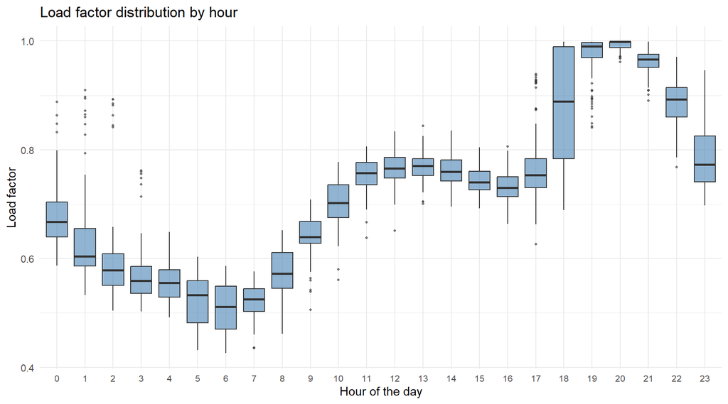

Load factor distribution by hour. True off-peak valley at hours 4-7; evening peak (hours 19-21) dominates over midday plateau (hours 11-16).

```r
ggplot(lf, aes(x = factor(hour), y = load_factor)) +
  geom_boxplot(fill = "steelblue", alpha = 0.6, outlier.size = 0.8) +
  labs(
    x     = "Hour of the day",
    y     = "Load factor",
    title = "Load factor distribution by hour"
  ) +
  theme_minimal(base_size = 11) +
  theme(axis.text.x = element_text(size = 8))
```

This hourly pattern will reappear in **Phase 3** (MAP component assignment as a function of hour) and **Phase 4** (multinomial logistic regression with Fourier-transformed hour as covariate).

## 5. Plot 3 — Density ridgeline by hour

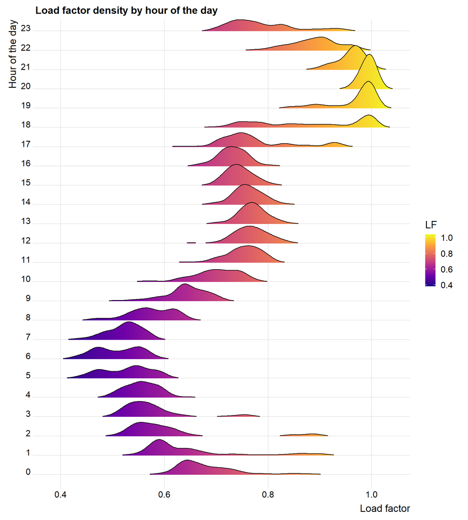

Load factor density for each of the 24 hours. Colour encodes the LF value.

```r
ggplot(lf, aes(x = load_factor, y = factor(hour), fill = after_stat(x))) +
  geom_density_ridges_gradient(scale = 1.8, rel_min_height = 0.01) +
  scale_fill_viridis_c(name = "LF", option = "C") +
  labs(
    x     = "Load factor",
    y     = "Hour of the day",
    title = "Load factor density by hour of the day"
  ) +
  theme_ridges(grid = TRUE)
```

## 6. Plot 4 — Mean load factor heatmap (hour x month)

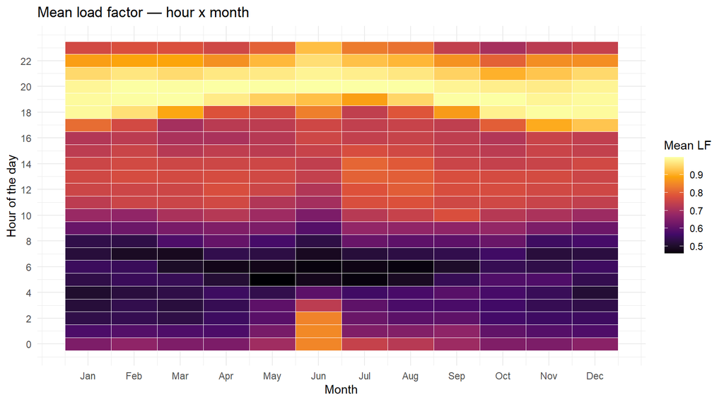

Mean load factor by hour and month. Summer months (June-August) show higher consumption in afternoon hours (air conditioning peak).

```r
lf |>
  group_by(hour, month) |>
  summarise(mean_lf = mean(load_factor), .groups = "drop") |>
  ggplot(aes(x = month, y = hour, fill = mean_lf)) +
  geom_tile(color = "white", linewidth = 0.3) +
  scale_fill_viridis_c(option = "B", name = "Mean LF") +
  scale_x_continuous(breaks = 1:12,
                     labels = c("Jan","Feb","Mar","Apr","May","Jun",
                                "Jul","Aug","Sep","Oct","Nov","Dec")) +
  scale_y_continuous(breaks = seq(0, 23, 2)) +
  labs(
    title = "Mean load factor — hour x month",
    x     = "Month",
    y     = "Hour of the day"
  ) +
  theme_minimal(base_size = 11)
```

The heatmap highlights two effects:

- **Daily cycle (dominant)**: the horizontal banding is the strongest signal — a dark band at hours 4–7 (deep off-peak, near LF ≈ 0.50) and a bright yellow-white band at hours 19–22 (evening peak, near LF ≈ 0.90+) run consistently across all 12 months.
- **Seasonal modulation (subtle)**: there is a mild brightening of the afternoon block (hours 12–17) in summer months (Jun–Aug), consistent with air-conditioning demand in Tetouan’s hot Mediterranean climate. However, the effect is modest compared to the daily cycle. A notable anomalous warm cell appears in June at hours 0–2, likely a sampling artifact from the 2000-row subsample rather than a genuine physical pattern.

The Fourier-transformed hour covariates used in **Phase 4** are designed to capture exactly the 24-hour periodicity — the dominant structure visible here.

## 7. Assessment of the single Beta approximation

```r
fit_beta <- fitdist(lf$load_factor, "beta")
cat("MLE parameters: alpha =", round(fit_beta$estimate["shape1"], 3),
    "| beta =", round(fit_beta$estimate["shape2"], 3), "\n")
```

```
## MLE parameters: alpha = 3.118 | beta = 1.093
```

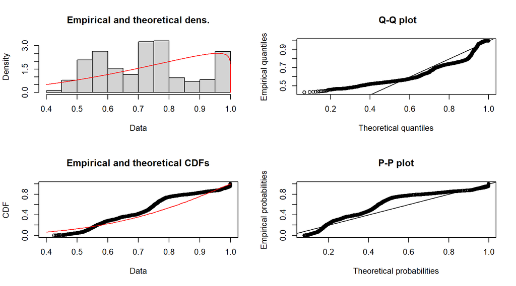

MLE diagnostics for a single Beta fit. Systematic deviations in the QQ-plot motivate the mixture model.

```r
plot(fit_beta)
```

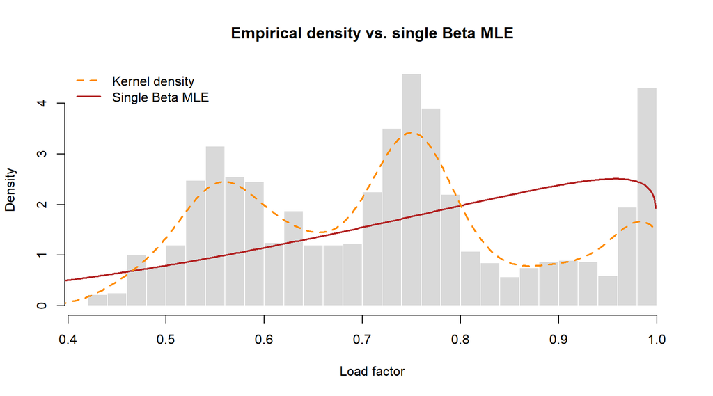

```r
hist(lf$load_factor, breaks = 35, freq = FALSE,
     col = "grey85", border = "white",
     xlab = "Load factor",
     main = "Empirical density vs. single Beta MLE")
x_seq <- seq(0.001, 0.999, length.out = 500)
lines(x_seq,
      dbeta(x_seq, fit_beta$estimate["shape1"], fit_beta$estimate["shape2"]),
      col = "firebrick", lwd = 2)
lines(density(lf$load_factor, from = 0.001, to = 0.999),
      col = "darkorange", lwd = 2, lty = 2)
legend("topleft",
       legend = c("Kernel density", "Single Beta MLE"),
       col    = c("darkorange", "firebrick"),
       lty    = c(2, 1), lwd = 2, bty = "n")
```

## Phase 1 summary

| Aspect | Finding |
| --- | --- |
| Overall distribution | Trimodal: off-peak ~0.52–0.55, midday plateau ~0.72–0.75, evening spike ~0.999 |
| Hourly pattern | Valley hours 4–7; hours 0–3 moderate; midday plateau 11–16; evening peak 19–21 |
| Seasonality | Daily cycle dominates; mild summer afternoon enhancement; anomaly in June hours 0–2 |
| Single Beta fit | Fails dramatically: MLE yields a J-shaped curve, misses all three modes |
| Mixture motivation | H = 3 components expected optimal (to be confirmed via WAIC in Phase 2) |

The structure identified here directly informs the modelling choices in subsequent phases:

- **Phase 2**: Beta mixture with $H \in \{1,\ldots,5\}$, model selection via WAIC
- **Phase 3**: MAP assignment — mixture components correspond to hourly regimes (off-peak / peak)
- **Phase 4**: multinomial logistic regression with covariates $\sin(k \cdot 2\pi h / 24)$, $\cos(k \cdot 2\pi h / 24)$ to capture the daily periodicity

# Phase 2: Beta mixture with $H \in \{1,\ldots,5\}$, model selection via WAIC

```r
cat("Estimate for the single beta model (H=1)...\n")

fit_h1 <- brm(
  formula = load_factor ~ 1,
  family = Beta(),
  data = lf,
  chains = 4,
  iter = 2000,
  seed = 42
)
fit_h1 <- add_criterion(fit_h1, "waic")

fit_h2 <- brm(
  formula = load_factor ~ 1,
  family = mixture(Beta, nmix = 2),
  data = lf,
  chains = 4, iter = 2000, seed = 42
)
fit_h2 <- add_criterion(fit_h2, "waic")

fit_h3 <- brm(
  formula = load_factor ~ 1,
  family = mixture(Beta, nmix = 3),
  data = lf,
  chains = 4, iter = 2000, seed = 42
)
fit_h3 <- add_criterion(fit_h3, "waic")

fit_h4 <- brm(
  formula = load_factor ~ 1,
  family = mixture(Beta, nmix = 4),
  data = lf,
  chains = 4, iter = 2000, seed = 42
)
fit_h4 <- add_criterion(fit_h4, "waic")

fit_h5 <- brm(
  formula = load_factor ~ 1,
  family = mixture(Beta, nmix = 5),
  data = lf,
  chains = 4, iter = 2000, seed = 42
)
fit_h5 <- add_criterion(fit_h5, "waic")
```

```r
library(brms)
library(ggplot2)
library(gridExtra)

fit_h1 <- readRDS("modello_H1.rds")
fit_h2 <- readRDS("modello_H2.rds")
fit_h3 <- readRDS("modello_H3.rds")
fit_h4 <- readRDS("modello_H4.rds")
fit_h5 <- readRDS("modello_H5.rds")

model_comparison <- loo_compare(fit_h1, fit_h2, fit_h3, fit_h4, fit_h5, criterion = "waic")
knitr::kable(as.data.frame(model_comparison), digits = 2, caption = "WAIC Comparison across Mixture Models")
```

WAIC Comparison across Mixture Models

|  | elpd_diff | se_diff | elpd_waic | se_elpd_waic | p_waic | se_p_waic | waic | se_waic |
| --- | --- | --- | --- | --- | --- | --- | --- | --- |
| fit_h5 | 0.00 | 0.00 | 1593.40 | 33.91 | 38.86 | 2.38 | -3186.79 | 67.83 |
| fit_h4 | -50.20 | 6.28 | 1543.20 | 34.79 | 77.82 | 1.72 | -3086.39 | 69.57 |
| fit_h3 | -219.06 | 14.14 | 1374.34 | 27.95 | 114.74 | 3.34 | -2748.67 | 55.89 |
| fit_h2 | -302.80 | 20.50 | 1290.59 | 25.25 | 24.63 | 1.08 | -2581.19 | 50.49 |
| fit_h1 | -776.40 | 35.41 | 816.99 | 15.94 | 2.83 | 0.17 | -1633.99 | 31.88 |

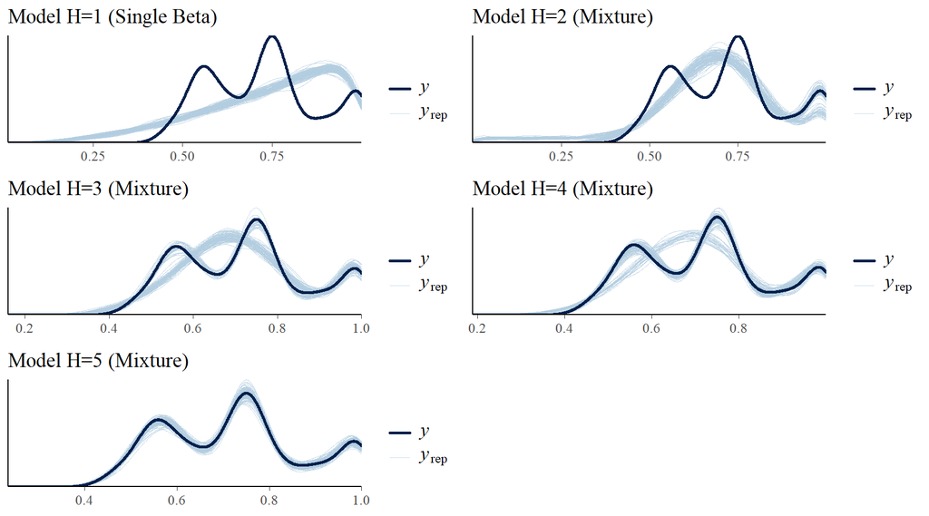

```r
p1 <- pp_check(fit_h1, ndraws = 100) + labs(title = "Model H=1 (Single Beta)")
p2 <- pp_check(fit_h2, ndraws = 100) + labs(title = "Model H=2 (Mixture)")
p3 <- pp_check(fit_h3, ndraws = 100) + labs(title = "Model H=3 (Mixture)")
p4 <- pp_check(fit_h4, ndraws = 100) + labs(title = "Model H=4 (Mixture)")
p5 <- pp_check(fit_h5, ndraws = 100) + labs(title = "Model H=5 (Mixture)")

grid.arrange(p1, p2, p3, p4, p5, ncol = 2)
```

Model selection using the WAIC criterion yielded a counterintuitive result compared to pure visual inspection. Although the empirical histogram suggests a trimodal structure ($H=3$), the 5-component mixture model ($H=5$) proves to be vastly superior, showing a highly significant predictive difference (elpd_diff = -50.2) compared to the $H=4$ model (se_diff = 6.3).This discrepancy suggests that the individual peaks (modes) present in the data possess complex asymmetry or tail behavior that a single Beta distribution cannot adequately parameterize. Consequently, the Bayesian process utilizes the additional mixture components not to identify new, isolated data clusters, but rather to correct and refine the shape of the individual empirical distributions. This ensures a significantly superior fit, ultimately justifying the penalty introduced by the WAIC for the higher parametric complexity.